# Heraldic Color Hatching

The `gridpattern` package supports heraldic color hatching via `grid.pattern_hatch()`. Hatching encodes color information using patterns of lines and dots, allowing images to be reproduced in black and white while retaining color identity.

Four systems are supported via the `subtype` argument:

- `"combinatorial"` (default): extends the seven standard Petra Sancta tinctures with systematically derived mixed-color combinations following three rules:
  1. white combined with a color is represented by dashed lines
  2. yellow combined with a color is represented by dotdash lines
  3. color combined with a color is represented by crossing solid lines
- `"fox-davies"`: contains the sixteen hatchings from Fox-Davies’ [*A Complete Guide to Heraldry*](https://en.wikisource.org/wiki/A_Complete_Guide_to_Heraldry/Chapter_7#74) covering the seven standard Petra Sancta tinctures plus nine extensions from German heraldry.
- `"goodman"`: contains all the hatchings from David Goodman’s [Heraldic Tincture](https://david.goodman.graphics/portfolio/item/crests-heraldry-and-coats-of-arms/) reference (v2.0, 2024).
- `"unicode"`: the system used in the official Unicode character chart pdfs to render “colored” (emoji) glyphs in black-and-white.

Use `names_hatch()` to query supported tincture names for a given subtype. The “hatch” pattern will also coerce some of the more common color names to the right tincture e.g. “gold” and “yellow” will be both coerced to “or” and vice versa.

```r
library("grid")
library("gridpattern")
```

```r
names_hatch()
```

```
#>  [1] "black"      "blue"       "brown"      "green"      "grey"
#>  [6] "lavender"   "light blue" "lime green" "magenta"    "mint green"
#> [11] "olive"      "orange"     "pink"       "purple"     "red"
#> [16] "rose"       "slate"      "teal"       "umbre"      "violet"
#> [21] "white"      "yellow"
```

```r
names_hatch("fox-davies")
```

```
#>  [1] "argent"       "azure"        "bleu celeste" "brunatre"     "carnation"
#>  [6] "cendree"      "eisenfarbe"   "gules"        "or"           "orange"
#> [11] "proper"       "purpure"      "sable"        "sanguine"     "tenne"
#> [16] "vert"
```

```r
names_hatch("goodman")
```

```
#>  [1] "argent"       "azure"        "bleu celeste" "bronze"       "brunatre"
#>  [6] "carnation"    "cendree"      "copper"       "gules"        "lead"
#> [11] "murrey"       "or"           "orange"       "purpure"      "rose"
#> [16] "sable"        "sanguine"     "steel"        "tenne"        "vert"
```

```r
names_hatch("unicode")
```

```
#>  [1] "black"      "blue"       "brown"      "green"      "grey"
#>  [6] "light blue" "orange"     "pink"       "purple"     "red"
#> [11] "white"      "yellow"
```

## Combinatorial color hatching

The default `"combinatorial"` subtype starts from the set of five [Munsell primary colors](https://en.wikipedia.org/wiki/Munsell_color_system) of red, yellow, green, blue, and purple plus black and white and the standard Petra Sancta color hatching system and then systematically derives additional color hatchings via three rules:

1. **white + color** → dashed lines
2. **yellow + color** → dotdash lines
3. **color + color** → crossing solid lines

## Heraldic tincture hatching

### Fox-Davies

The `"fox-davies"` hatching subtype includes the seven standard tinctures plus nine extensions from German heraldry whose hatchings were included in Fox-Davies’ [*A Complete Guide to Heraldry*](https://en.wikisource.org/wiki/A_Complete_Guide_to_Heraldry/Chapter_7#74).

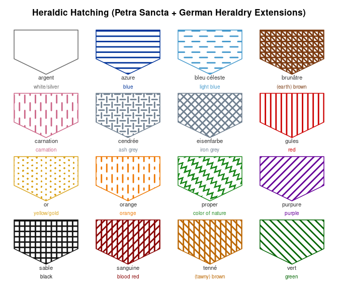

### Goodman

The `"goodman"` hatching subtype includes all the hatchings in David Goodman’s [Heraldic Tincture](https://david.goodman.graphics/portfolio/item/crests-heraldry-and-coats-of-arms/) reference (v2.0, 2024). This shares most hatchings with Fox-Davies but differs in few ways:

- Goodman’s **sanguine** hatching instead uses horizontal plus diagonal `\` crossing lines.
- Goodman also has a distinct **murrey** hatching which uses crossing diagonal lines (Fox-Davies’ instead uses this hatching for the eisenfarbe (iron grey) hatching).
- New **rose** with the same hatching as carnation (which Goodman also lists).
- New **steel** metal rendered as plus signs in a square grid.
- New **copper**, **bronze**, and **lead** metals which are each rendered as the letter “c” in a hex grid.
- Goodman omits the **proper** hatching that Fox-Davies included.

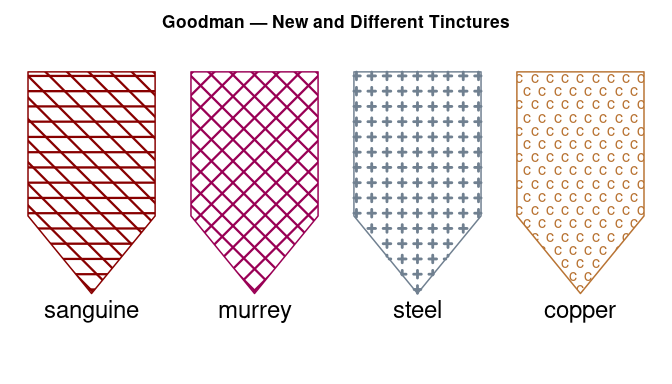

## Unicode color hatching

The `"unicode"` hatching subtype provides each of the hatching used in the official Unicode character chart pdfs to assign a distinct pattern to each color to render “colored” (emoji) glyphs in black-and-white. Notably Unicode has twelve different [colored heart emoji](https://unicode.org/emoji/charts/full-emoji-list.html#heart) (red, blue, green, yellow, purple, black, white, brown, orange, light blue, grey, pink) that each needed a separate hatching.

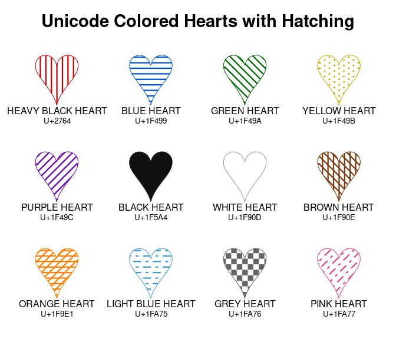

## Okabe-Ito hatching

One of the techniques to meet Web Content Accessibility Guidelines (WCAG) is to [use color and pattern](https://www.w3.org/WAI/WCAG21/Techniques/general/G111) to ensure things are accessible to the color-blind.

The [Okabe-Ito palette](https://jfly.uni-koeln.de/color/) is a widely used colorblind-friendly palette. Here is an example of adding a simple hatching scheme to go with this palette to provide visual redundancy:

- “yellow”, “blue”, and “white” are given their standard Petra Sancta hatchings
- “reddish purple” is given a “purple” Petra Sancta hatching
- “bluish green” is given a “green” Petra Sancta hatching
- “vermillion” (red orange) is given a “red” Petra Sancta hatching
- we use a simple black fill for “black” instead of a “sable” crosshatch
- “orange” and “sky blue” are given the hatchings from German heraldry (see Fox-Davies’ section above)

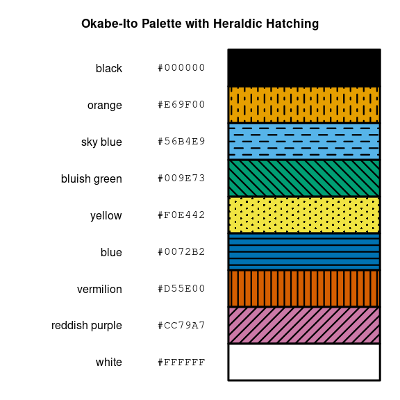

```r
oi_names <- c(
    "black", "orange", "sky blue", "bluish green",
    "yellow", "blue", "vermilion", "reddish purple", "white"
)
oi_hex <- c(
    "#000000", "#E69F00", "#56B4E9", "#009E73",
    "#F0E442", "#0072B2", "#D55E00", "#CC79A7", "#FFFFFF"
)
oi_hatch <- c(
    NA, "orange", "bleu celeste", "vert",
    "or", "azure", "gules", "purpure", NA
)
sx <- c(0, 0, 1, 1)
sy <- c(1, 0, 0, 1)
n <- length(oi_names)

grid.newpage()
grid.rect(gp = gpar(fill = "white", col = NA))
pushViewport(viewport(width = 0.90, height = 0.94))
grid.text(
    "Okabe-Ito Palette with Heraldic Hatching",
    y = unit(1, "npc") - unit(0.25, "cm"),
    just = "top",
    gp = gpar(fontsize = 13, fontface = "bold")
)
pushViewport(viewport(
    y = 0.46, height = 0.88,
    layout = grid.layout(
        n, 3,
        widths = unit(c(3, 2.5, 4), "null"),
        heights = unit(rep(1, n), "null")
    )
))

for (i in seq_len(n)) {
    grid.text(oi_names[i], x = 0.90, just = "right",
              gp = gpar(fontsize = 12, col = "black"),
              vp = viewport(layout.pos.row = i, layout.pos.col = 1))

    grid.text(oi_hex[i],
              gp = gpar(fontsize = 12, fontfamily = "mono", col = "black"),
              vp = viewport(layout.pos.row = i, layout.pos.col = 2))

    pushViewport(viewport(layout.pos.row = i, layout.pos.col = 3))
    grid.rect(gp = gpar(fill = oi_hex[i], col = "black", lwd = 3.0))
    if (!is.na(oi_hatch[i])) {
        grid.pattern_hatch(sx, sy, type = oi_hatch[i],
                           colour = "black", spacing = 0.18, linewidth = 0.8)
    }
    popViewport()
}

popViewport()
popViewport()
```